# Nebraska Farmers Market Demo

## 1 Overview

This document walks through the workflow of creating interactive visualizations using R Shiny, beginning with exploratory data analysis–including data processing, merging, and reshaping–to prepare the data for use in a dashboard. A demo dashboard featuring interactive visualizations for exploring product diversity by growers at the county, and market levels is included at the end.

The data was collected from the [Nebraska Farmers Market Online Database](https://nebraska-nda.caseapp.tylerapp.com/page.request.do?page=page.FM.Landing) via web scraping. For this demo, a sample of growers who sell produce across 20 counties in Nebraska was selected.

The code and datasets used for the demo can be found on: https://github.com/peiychen/NE-farmers-market-demo.

**Acknowledgment**: This document was annotated and refined with the assistance of ChatGPT, which helped clarify, expand, and proofread both narrative and code documentation.

## 2 Data Exploration

### 2.1 Load Required Packages and Import Datasets

Packages used:

- `here`: Simplifies file referencing by creating paths relative to the project root.
- `janitor`: Provides tools for data cleaning, especially column name formatting.
- `tidyverse`: A collection of R packages for data manipulation, visualization, and analysis.

Key functions:

- `theme_set()`: Sets the default theme for all `ggplot2` visualizations.
- `theme()`: Customizes specific theme elements like grid lines for cleaner plots.

```r
# Clear the environment to avoid conflicts with existing objects
rm(list = ls())

# Load necessary packages
library(here)
library(janitor)
library(tidyverse)

# Set a clean and minimal default theme for ggplot2 visualizations
theme_set(
  theme_minimal() +
    theme(
      panel.grid = element_line(linewidth = 1/5), # Thinner grid lines
      panel.grid.minor = element_blank(),         # Remove minor grid lines
      panel.grid.major.y = element_blank()        # Remove horizontal major grid lines
    )
)

# Import datasets using relative file paths
grower_data  <- readRDS(here("data", "grower_sample.rds"))  # RDS file containing detailed grower data
vendor_info  <- read_csv(here("data", "vendor_info.csv"),
                         show_col_types = FALSE)            # CSV file with vendor details
market_info  <- read_csv(here("data", "market_info.csv"),
                         show_col_types = FALSE)            # CSV file with market details
```

### 2.2 Initial Glance at the Data: `grower_data`

```r
# Check the dimensions of the dataset (rows x columns)
dim(grower_data)
```

```
[1] 136   7
```

```r
# Display the names of all columns in the dataset
names(grower_data)
```

```
[1] "grower_name"      "grower_option"    "grower_market"    "grower_fruit"
[5] "grower_vegetable" "grower_website"   "grower_herb"
```

```r
# View the first 6 rows of the dataset to preview the data
# head(grower_data)
```

- Unit of Analysis: Each row in the dataset represents a **grower**
- Columns of Interest:
  - `grower_name`: Name of the grower/vendor
  - `grower_market`: The markets where the grower sells products
  - `grower_vegetable`: Vegetables sold by the grower
  - `grower_fruit`: Fruits sold by the grower
  - `grower_herb`: Herbs sold by the grower

```r
# Preview the first few entries in each key column
head(grower_data$grower_market)
```

```
$g2540
[1] "Morrill Farmers Market"

$g2934
[1] "Omaha Farmers Market in Aksarben Village"
[2] "Sunday Farmers Market at College View (Lincoln)"

$g2829
[1] "Gothenburg Farmers Market"

$g2845
[1] "Blair Farmers Market"             "Lyons Main Street Farmers Market"

$g2667
[1] "Bennet Farmers Market"   "Syracuse Farmers Market"

$g2693
[1] "Omaha Farmers Market in Aksarben Village"
[2] "Omaha Farmers Market in the Old Market"
[3] "Papillion Farmers Market"
```

```r
head(grower_data$grower_vegetable)
```

```
$g2540
 [1] "BEANS"       "CABBAGE"     "CARROTS"     "CUCUMBERS"   "HORSERADISH"
 [6] "INDIAN_CORN" "KOHLRABI"    "LEEKS"       "OKRA"        "PEPPERS"
[11] "PUMPKINS"    "SHALLOTS"    "SQUASHES"    "SWEET_CORN"  "TOMATILLOS"
[16] "TOMATOES"    "ZUCCHINI"

$g2934
 [1] "BEANS"       "BEETS"       "KALE"        "LETTUCES"    "MUSHROOMS"
 [6] "ONIONS"      "PEPPERS"     "POTATOES"    "RADISHES"    "SALAD_MIXES"
[11] "SWEET_CORN"  "TOMATOES"    "ZUCCHINI"

$g2829
[1] "BEANS"     "CUCUMBERS" "EGGPLANT"  "RHUBARB"   "SQUASHES"  "TOMATOES"
[7] "ZUCCHINI"

$g2845
 [1] "BEANS"          "BEETS"          "CABBAGE"        "CARROTS"
 [5] "CUCUMBERS"      "EGGPLANT"       "GREEN_ONIONS"   "INDIAN_CORN"
 [9] "KOHLRABI"       "LETTUCES"       "ONIONS"         "PEAS"
[13] "PEPPERS"        "POTATOES"       "PUMPKINS"       "RADISHES"
[17] "RHUBARB"        "SQUASHES"       "SWEET_CORN"     "SWEET_POTATOES"
[21] "TOMATOES"       "ZUCCHINI"

$g2667
 [1] "ASPARAGUS"    "BEANS"        "BROCCOLI"     "CABBAGE"      "CUCUMBERS"
 [6] "GARLIC"       "GREEN_ONIONS" "LETTUCES"     "PEPPERS"      "POTATOES"
[11] "RADISHES"     "RHUBARB"      "SQUASHES"     "TOMATOES"     "ZUCCHINI"

$g2693
 [1] "BEETS"       "CUCUMBERS"   "EGGPLANT"    "GARLIC"      "OKRA"
 [6] "ONIONS"      "PEPPERS"     "PUMPKINS"    "RADISHES"    "SQUASHES"
[11] "SWEET_CORN"  "SWISS_CHARD" "TOMATOES"    "ZUCCHINI"
```

```r
head(grower_data$grower_fruit)
```

```
$g2540
[1] "CANTALOUPES"

$g2934
character(0)

$g2829
character(0)

$g2845
[1] "APPLES"       "CANTALOUPES"  "STRAWBERRIES" "WATERMELONS"

$g2667
[1] "CANTALOUPES"   "CHERRIES"      "CHOKECHERRIES" "GOOSEBERRIES"
[5] "MULBERRIES"    "RASPBERRIES"   "STRAWBERRIES"  "WATERMELONS"

$g2693
[1] "APPLES"       "CANTALOUPES"  "STRAWBERRIES" "WATERMELONS"
```

```r
head(grower_data$grower_herb)
```

```
$g2540
character(0)

$g2934
character(0)

$g2829
[1] "BASIL"    "OREGANO"  "ROSEMARY"

$g2845
 [1] "BASIL"       "CAMOMILE"    "CILANTRO"    "CORIANDERS"  "DILL"
 [6] "LAVENDERS"   "LEMON_BALMS" "OREGANO"     "PARSLEY"     "ROSEMARY"
[11] "SAGE"        "THYME"

$g2667
character(0)

$g2693
 [1] "ANISE"     "BASIL"     "CAMOMILE"  "CHIVES"    "CILANTRO"  "DILL"
 [7] "LAVENDERS" "MARJORAM"  "MINTS"     "OREGANO"   "PARSLEY"   "ROSEMARY"
[13] "SAGE"      "TARRAGON"  "THYME"
```

### 2.3 Create Separate Data Frames

This step prepares individual data frames for different product types by extracting and cleaning relevant columns.

Key functions:

- `select()`: Selects specific variables from a data frame (can also be used to rename them).
- `unnest()`: Expands list-columns into regular rows and columns.
  - `keep_empty = TRUE`: Ensures that all growers are retained in the output, even if they do not sell a particular type of product.
- `str_trim()`: Removes leading and trailing white space from character strings.

```r
grower_market = grower_data |>
  select(grower_name, grower_market) |>
  unnest(c(grower_name, grower_market), keep_empty = TRUE)

# Preview the results
grower_market
```

```
# A tibble: 235 × 2
   grower_name           grower_market
   <chr>                 <chr>
 1 A & C Farm            Morrill Farmers Market
 2 Abie Vegetable People Omaha Farmers Market in Aksarben Village
 3 Abie Vegetable People Sunday Farmers Market at College View (Lincoln)
 4 Aden Creative         Gothenburg Farmers Market
 5 Anderson Produce      Blair Farmers Market
 6 Anderson Produce      Lyons Main Street Farmers Market
 7 Arnold's Acres        Bennet Farmers Market
 8 Arnold's Acres        Syracuse Farmers Market
 9 Ba-Dra-Mi Farms       Omaha Farmers Market in Aksarben Village
10 Ba-Dra-Mi Farms       Omaha Farmers Market in the Old Market
# ℹ 225 more rows
```

```r
# Remove leading/trailing white space from grower names
grower_market$grower_name = str_trim(grower_market$grower_name)
```

```r
grower_veggie = grower_data |>
  select(grower_name, grower_vegetable) |>
  unnest(cols = c(grower_name, grower_vegetable), keep_empty = TRUE)

# Preview the results
grower_veggie
```

```
# A tibble: 2,063 × 2
   grower_name grower_vegetable
   <chr>       <chr>
 1 A & C Farm  BEANS
 2 A & C Farm  CABBAGE
 3 A & C Farm  CARROTS
 4 A & C Farm  CUCUMBERS
 5 A & C Farm  HORSERADISH
 6 A & C Farm  INDIAN_CORN
 7 A & C Farm  KOHLRABI
 8 A & C Farm  LEEKS
 9 A & C Farm  OKRA
10 A & C Farm  PEPPERS
# ℹ 2,053 more rows
```

```r
# Trim white space from grower names
grower_veggie$grower_name = str_trim(grower_veggie$grower_name)
```

```r
grower_fruit = grower_data |>
  select(grower_name, grower_fruit) |>
  unnest(cols = c(grower_name, grower_fruit), keep_empty = TRUE)

# Preview the results
grower_fruit
```

```
# A tibble: 397 × 2
   grower_name           grower_fruit
   <chr>                 <chr>
 1 A & C Farm            CANTALOUPES
 2 Abie Vegetable People <NA>
 3 Aden Creative         <NA>
 4 Anderson Produce      APPLES
 5 Anderson Produce      CANTALOUPES
 6 Anderson Produce      STRAWBERRIES
 7 Anderson Produce      WATERMELONS
 8 Arnold's Acres        CANTALOUPES
 9 Arnold's Acres        CHERRIES
10 Arnold's Acres        CHOKECHERRIES
# ℹ 387 more rows
```

```r
# Trim white space from grower names
grower_fruit$grower_name = str_trim(grower_fruit$grower_name)
```

```r
grower_herb = grower_data |>
  select(grower_name, grower_herb) |>
  unnest(cols = c(grower_name, grower_herb), keep_empty = TRUE)

# Preview the results
grower_herb
```

```
# A tibble: 520 × 2
   grower_name           grower_herb
   <chr>                 <chr>
 1 A & C Farm            <NA>
 2 Abie Vegetable People <NA>
 3 Aden Creative         BASIL
 4 Aden Creative         OREGANO
 5 Aden Creative         ROSEMARY
 6 Anderson Produce      BASIL
 7 Anderson Produce      CAMOMILE
 8 Anderson Produce      CILANTRO
 9 Anderson Produce      CORIANDERS
10 Anderson Produce      DILL
# ℹ 510 more rows
```

```r
# Trim white space from grower names
grower_herb$grower_name = str_trim(grower_herb$grower_name)
```

### 2.4 Summarize Number of Vegetables, Fruits, and Herbs per Grower

This section calculates how many different items (vegetables, fruits, or herbs) each grower sells.

Key functions:

- `mutate()`: Creates a new column (`count`) to indicate whether a product is present (`1`) or missing (`0`).
- `group_by()`: Groups the data by `grower_name` to prepare for summarization.
- `summarize()`: Aggregates the data to compute the number of items sold per grower.

```r
grower_veggie |>
  mutate(count = case_when(is.na(grower_vegetable) ~ 0, TRUE ~ 1)) |>
  group_by(grower_name) |>
  summarize(n_veggie = sum(count)) -> grower_veggie_n

# View the summarized data
grower_veggie_n
```

```
# A tibble: 136 × 2
   grower_name           n_veggie
   <chr>                    <dbl>
 1 A & C Farm                  17
 2 Abie Vegetable People       13
 3 Aden Creative                7
 4 Anderson Produce            22
 5 Arnold's Acres              15
 6 Ba-Dra-Mi Farms             14
 7 Bao Nhia Thao               24
 8 Beavers Produce             25
 9 Biermans of Arnold          12
10 Big Muddy Urban Farm        32
# ℹ 126 more rows
```

```r
grower_fruit |>
  mutate(count = case_when(is.na(grower_fruit) ~ 0, TRUE ~ 1)) |>
  group_by(grower_name) |>
  summarize(n_fruit = sum(count)) -> grower_fruit_n

# View the summarized data
grower_fruit_n
```

```
# A tibble: 136 × 2
   grower_name           n_fruit
   <chr>                   <dbl>
 1 A & C Farm                  1
 2 Abie Vegetable People       0
 3 Aden Creative               0
 4 Anderson Produce            4
 5 Arnold's Acres              8
 6 Ba-Dra-Mi Farms             4
 7 Bao Nhia Thao               1
 8 Beavers Produce             2
 9 Biermans of Arnold          0
10 Big Muddy Urban Farm        7
# ℹ 126 more rows
```

```r
grower_herb |>
  mutate(count = case_when(is.na(grower_herb) ~ 0, TRUE ~ 1)) |>
  group_by(grower_name) |>
  summarize(n_herb = sum(count)) -> grower_herb_n

# View the summarized data
grower_herb_n
```

```
# A tibble: 136 × 2
   grower_name           n_herb
   <chr>                  <dbl>
 1 A & C Farm                 0
 2 Abie Vegetable People      0
 3 Aden Creative              3
 4 Anderson Produce          12
 5 Arnold's Acres             0
 6 Ba-Dra-Mi Farms           15
 7 Bao Nhia Thao             11
 8 Beavers Produce            7
 9 Biermans of Arnold         0
10 Big Muddy Urban Farm      19
# ℹ 126 more rows
```

### 2.5 Merge Product Data and Compute Total Products Sold

This step combines the summarized counts of vegetables, fruits, and herbs sold by each grower into a single data frame, and calculates the total number of products per grower.

Key functions:

- `full_join()`: Merges data frames while retaining all growers, even if they don’t sell certain product types.
- `rowSums()`: Computes the total number of products (across vegetables, fruits, and herbs) for each grower, while handling missing values.

```r
# Merge product-specific data frames
grower_product = grower_fruit_n |>
  full_join(grower_veggie_n) |>
  full_join(grower_herb_n)
# Calculate total number of products sold by each grower
grower_product = grower_product |>
  mutate(n_product = rowSums(grower_product[, 2:4], na.rm = TRUE))

# View the result
grower_product
```

```
# A tibble: 136 × 5
   grower_name           n_fruit n_veggie n_herb n_product
   <chr>                   <dbl>    <dbl>  <dbl>     <dbl>
 1 A & C Farm                  1       17      0        18
 2 Abie Vegetable People       0       13      0        13
 3 Aden Creative               0        7      3        10
 4 Anderson Produce            4       22     12        38
 5 Arnold's Acres              8       15      0        23
 6 Ba-Dra-Mi Farms             4       14     15        33
 7 Bao Nhia Thao               1       24     11        36
 8 Beavers Produce             2       25      7        34
 9 Biermans of Arnold          0       12      0        12
10 Big Muddy Urban Farm        7       32     19        58
# ℹ 126 more rows
```

### 2.6 Plot: Bar Chart of Products Sold per Grower

This section reshapes the data and visualizes the number of vegetables, fruits, and herbs sold by each grower using a horizontal stacked bar chart.

#### 2.6.1 Reshape to long format

Convert wide-format summary data into long format for plotting.

Key functions:

- `pivot_longer`: Converts data from wide format to long format. This is useful for plotting or performing grouped operations across multiple columns. In this case, it turns the columns `n_veggie`, `n_fruit`, and `n_herb` into two columns:
  - `name`: The original column names
  - `value`: The corresponding values for each grower

```r
grower_product_long = grower_product |>
  pivot_longer(cols = n_fruit:n_herb)

# Preview reshaped data
grower_product_long
```

```
# A tibble: 408 × 4
   grower_name           n_product name     value
   <chr>                     <dbl> <chr>    <dbl>
 1 A & C Farm                   18 n_fruit      1
 2 A & C Farm                   18 n_veggie    17
 3 A & C Farm                   18 n_herb       0
 4 Abie Vegetable People        13 n_fruit      0
 5 Abie Vegetable People        13 n_veggie    13
 6 Abie Vegetable People        13 n_herb       0
 7 Aden Creative                10 n_fruit      0
 8 Aden Creative                10 n_veggie     7
 9 Aden Creative                10 n_herb       3
10 Anderson Produce             38 n_fruit      4
# ℹ 398 more rows
```

#### 2.6.2 Define factor order and labels

Set the desired order and labels for product categories.

```r
product_order = c("n_veggie", "n_fruit", "n_herb")
product_label = c("Vegetable", "Fruit", "Herb")
```

#### 2.6.3 Create horizontal stacked bar chart

Plot the total number of products sold per grower, grouped by product type.

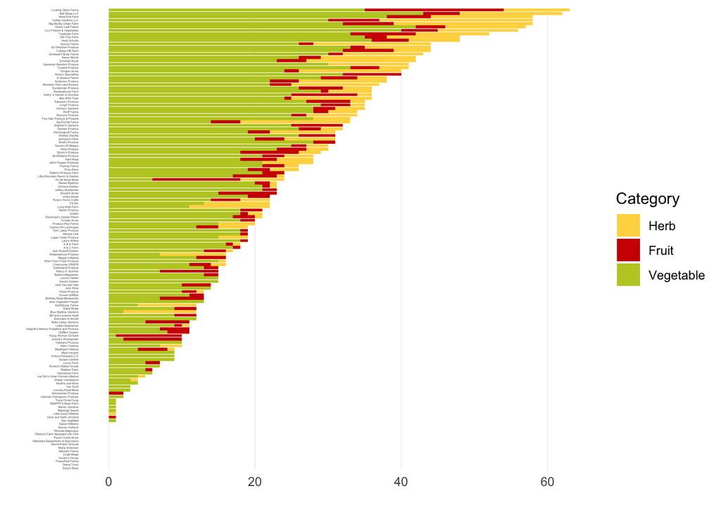

```r
grower_product_long |>
  mutate(grower_name = fct_reorder(grower_name, n_product), # Order growers by total product count
         name = factor(name,
                       levels = rev(product_order),         # Set order for stacking
                       labels = rev(product_label))) |>     # Apply readable labels
  ggplot(aes(x = value, y = grower_name, fill = name)) +
  geom_col() +
  labs(x = "", y = "", fill = "Category") +
        scale_fill_manual(values = c("#ffd74f", "#d00000", "#bccb2a")) +
  theme(axis.text.y = element_text(size = 2))
```

### 2.7 County-Level Summary of Product Sales

We extend our analysis by grouping growers by county to explore regional trends in product diversity.

#### 2.7.1 Step 1: Inspect `market_info` data

Check the structure of the `market_info` dataset to identify relevant columns for joining.

```r
names(market_info)
```

```
[1] "name"            "market_location" "city"            "state"
[5] "zip_code"        "county"          "hours"
```

```r
head(market_info)
```

```
# A tibble: 6 × 7
  name                         market_location city  state zip_code county hours
  <chr>                        <chr>           <chr> <chr>    <dbl> <chr>  <chr>
1 18th Street Farmers Market … 1800 Broadway … Scot… NE       69361 SCOTT… June…
2 Alma Farmers Market          Main Street     Alma  NE       68920 HARLAN 9 am…
3 Aurora Market on the Square  Courthouse Squ… Auro… NE       68801 HAMIL… June…
4 Beatrice Downtown Farmers M… 6th & High Str… Beat… NE       68310 GAGE   Mid-…
5 Beaver City Farmers Market   9th and O St    Beav… NE       68926 FURNAS June…
6 Bellevue Farmers Market      20th Ave and F… Bell… NE       68123 SARPY  June…
```

#### 2.7.2 Step 2: Add county information to `grower_market` data

Use `left_join()` to merge county information into the `grower_market` data based on market names.

```r
# Merge market info to include county data
grower_market_info = grower_market |>
  left_join(market_info |>
              select(name, county),
            by = join_by(grower_market == name))

# Preview result
grower_market_info
```

```
# A tibble: 235 × 3
   grower_name           grower_market                                   county
   <chr>                 <chr>                                           <chr>
 1 A & C Farm            Morrill Farmers Market                          SCOTTS…
 2 Abie Vegetable People Omaha Farmers Market in Aksarben Village        DOUGLAS
 3 Abie Vegetable People Sunday Farmers Market at College View (Lincoln) LANCAS…
 4 Aden Creative         Gothenburg Farmers Market                       DAWSON
 5 Anderson Produce      Blair Farmers Market                            KS_WAS…
 6 Anderson Produce      Lyons Main Street Farmers Market                BURT
 7 Arnold's Acres        Bennet Farmers Market                           LANCAS…
 8 Arnold's Acres        Syracuse Farmers Market                         OTOE
 9 Ba-Dra-Mi Farms       Omaha Farmers Market in Aksarben Village        DOUGLAS
10 Ba-Dra-Mi Farms       Omaha Farmers Market in the Old Market          DOUGLAS
# ℹ 225 more rows
```

#### 2.7.3 Step 3: Combine with `grower_product` data

Now, enrich the grower-level product data with county information for each grower.

Key functions:

- `left_join()`: Merges two data frames by matching rows based on a common key (in this case, market names and grower names).
  - `join_by()`: Allows you to specify the join condition when the column names differ between the two tables.
  - `relationship = "many-to-one"`: Ensures the join logic respects the expected data structure—many growers can map to one row in `grower_product.`

```r
grower_data = grower_market_info |>
  select(grower_name, grower_market, county) |>
  left_join(grower_product, by = "grower_name",
            relationship = "many-to-one")

# Preview final data with county information
grower_data
```

```
# A tibble: 235 × 7
   grower_name           grower_market  county n_fruit n_veggie n_herb n_product
   <chr>                 <chr>          <chr>    <dbl>    <dbl>  <dbl>     <dbl>
 1 A & C Farm            Morrill Farme… SCOTT…       1       17      0        18
 2 Abie Vegetable People Omaha Farmers… DOUGL…       0       13      0        13
 3 Abie Vegetable People Sunday Farmer… LANCA…       0       13      0        13
 4 Aden Creative         Gothenburg Fa… DAWSON       0        7      3        10
 5 Anderson Produce      Blair Farmers… KS_WA…       4       22     12        38
 6 Anderson Produce      Lyons Main St… BURT         4       22     12        38
 7 Arnold's Acres        Bennet Farmer… LANCA…       8       15      0        23
 8 Arnold's Acres        Syracuse Farm… OTOE         8       15      0        23
 9 Ba-Dra-Mi Farms       Omaha Farmers… DOUGL…       4       14     15        33
10 Ba-Dra-Mi Farms       Omaha Farmers… DOUGL…       4       14     15        33
# ℹ 225 more rows
```

### 2.8 Focus on a Specific County: LANCASTER

We now filter the dataset to only include growers from **LANCASTER** county and recreate the stacked bar chart for this subset.

#### 2.8.1 Filter, reshape, and prepare data for plotting

Key functions recap:

- `filter()`: Selects rows that meet specific criteria (here, county = “LANCASTER”).
- `distinct()`: Removes duplicate rows to ensure clean counts.
- `pivot_longer()`: Reshapes data from wide to long format for plotting.
- `fct_reorder()`: Orders factor levels based on another variable (helps with sorting in plots).

```r
grower_data_county = grower_data |>
  filter(county == "LANCASTER") |>                               # Keep only LANCASTER county
  distinct(grower_name, n_fruit, n_veggie, n_herb, n_product) |> # Remove duplicates
  mutate(grower_name = fct_reorder(grower_name, n_product)) |>   # Reorder growers by total products
  pivot_longer(cols = n_fruit:n_herb) |>                         # Convert to long format
  mutate(name = factor(
    name,
    level = rev(product_order), # Ensure consistent order
    label = rev(product_label)  # Use readable labels
  ))
```

#### 2.8.2 Plot: Products sold by growers in LANCASTER county

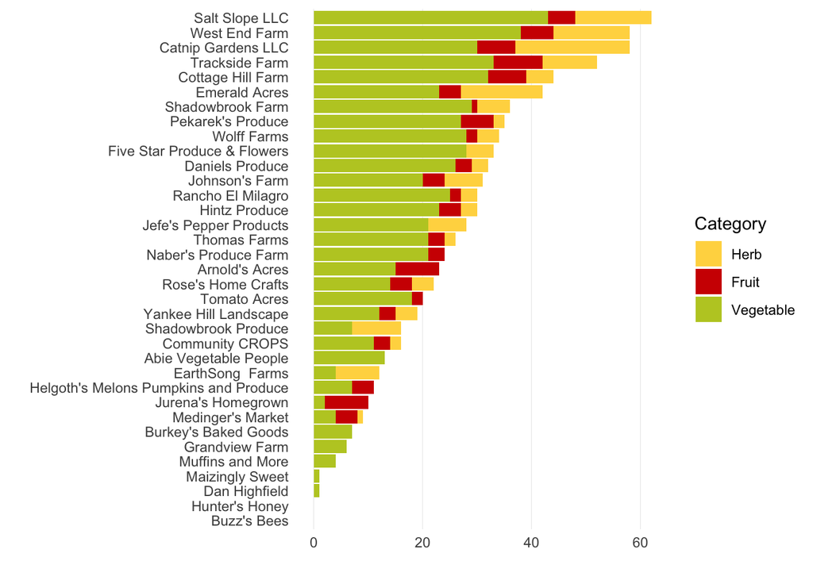

```r
grower_data_county |>
  mutate(grower_name = fct_reorder(grower_name, n_product)) |>
  ggplot(aes(x = value, y = grower_name,
             fill = name)) +
  geom_col() +
  labs(x = "", y = "", fill = "Category") +
        scale_fill_manual(values = c("#ffd74f", "#d00000", "#bccb2a"))
```

### 2.9 Focus on a Specific Farmers Market: Lincoln Haymarket

Now we narrow the focus even further by filtering for a specific farmers market within **LANCASTER** county: **Lincoln Haymarket Farmers Market**.

#### 2.9.1 Filter, Reshape, and Prepare Data

```r
grower_data_market = grower_data |>
  filter(county == "LANCASTER",
         grower_market == "Lincoln Haymarket Farmers Market") |> # Focus on one market
  distinct(grower_name, n_fruit, n_veggie, n_herb, n_product) |> # Remove duplicates
  mutate(grower_name = fct_reorder(grower_name, n_product)) |>   # Order by product count
  pivot_longer(cols = n_fruit:n_herb) |>                         # Reshape for plotting
  mutate(name = factor(
    name,
    level = rev(product_order), # Ensure consistent stacking order
    label = rev(product_label)  # Use readable labels
  ))
```

#### 2.9.2 Plot: Product mix at Lincoln Haymarket Farmers Market

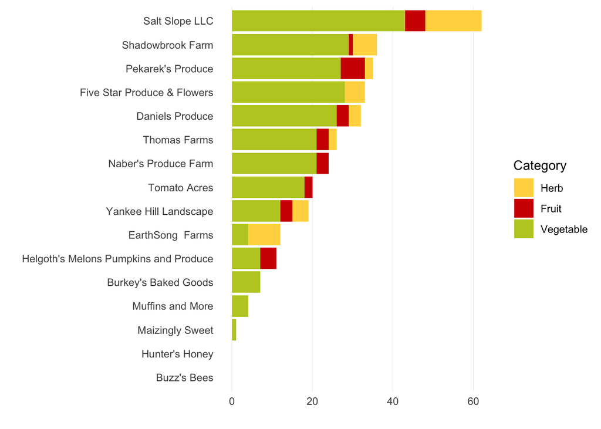

```r
grower_data_market |>
  mutate(grower_name = fct_reorder(grower_name, n_product)) |>
  ggplot(aes(x = value, y = grower_name,
             fill = name)) +
  geom_col() +
  labs(x = "", y = "", fill = "Category") +
        scale_fill_manual(values = c("#ffd74f", "#d00000", "#bccb2a"))
```

## 3 Prepare Data for Shiny Dashboard Demo

This section prepares key objects for use in a **Shiny dashboard**, focusing on dynamically populating dropdown menus and preserving preprocessed data.

### 3.1 Select Counties for Dashboard Dropdown

Here, we extract and format the list of counties that will be available as options in the dashboard’s dropdown selector.

Key functions:

- `tabyl()`: Quickly tabulates counts of unique values (from the `janitor` package).
- `arrange()`: Orders rows based on specified columns.
- `pull()`: Extracts a column as a vector.
- `str_to_upper()`: Converts character strings to uppercase.

```r
grower_market_info |>
  tabyl(county) |>              # Count growers per county
  arrange(desc(n)) |>           # Sort counties by number of growers (descending)
  pull(county) -> county_choice # Extract county names into a vector

# Standardize to uppercase for consistent display
county_choice = str_to_upper(county_choice)
```

### 3.2 Save Objects for Shiny App

Save the prepared data and menu options to an `.RData` file so they can be easily loaded into the Shiny app.

- `save()`: Saves R objects to a file for later use (especially useful for R data wrangling).

```r
save(grower_data, county_choice, file = here("gen", "demo.RData"))
```

## 4 Shiny Dashboard Demo

### 4.1 UI Components

This is a simple UI layout that allows users to select a county and market, and then view an interactive plot of growers and their products.

```r
# Dropdown for county selection
selectInput(
  inputId = "county",               # ID used in server logic
  label = "County",                 # Label shown to user
  choices = c("Please select" = "", # Default placeholder option
              county_choice)        # Dynamic list of county options
)
```

County

```r
# Dropdown for farmers market selection (to be populated reactively)
selectInput(
  inputId = "market",
  label = "Farmers Market",
  choices = c("Please select" = "")  # Initially empty, filled based on county input
)
```

Farmers Market

```r
# Output slot for interactive plot
plotlyOutput("grower")               # Render plot with Plotly for interactivity
```

[interactive chart not shown]

### 4.2 Server Logic and Interactive Plotting

The server handles reactive filtering by county and market, updates UI inputs, and generates an interactive bar chart using Plotly.